# Customizing R Base Plots

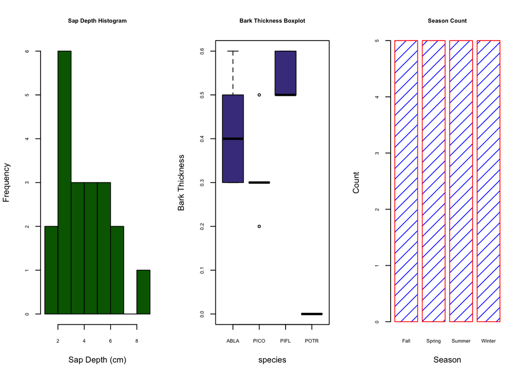

R has a plethora of plotting packages, tools, and techniques. Generally speaking, base R graphs aren’t as popular amongst advanced R users as others (e.g. `ggplot`). That being said, R base graphing offers a variety of styling techniques and unique customization. The base R plotting methods will offer a solid foundation before we learn more about the aforementioned `ggplot`.

Boxplots, histograms, pie charts, bar charts, and scatter plots are readily available and customizable in the base R plotting package. We can customize and style colors, text, line types, plotting symbols, line thicknesses, symbol size, and much more.

## Expanding on Basic Plots in R

Variable Assignment & Operations

```r
x = 7
y = 9
z <- y * (x/2 + 7) + sqrt(y)

print(x)
```

```
## [1] 7
```

```r
y
```

```
## [1] 9
```

```r
z
```

```
## [1] 97.5
```

```r
X <- 1:20
Y <- (1 + 1/X) + 2
X
```

```
##  [1]  1  2  3  4  5  6  7  8  9 10 11 12 13 14 15 16 17 18 19 20
```

```r
Y
```

```
##  [1] 4.000000 3.500000 3.333333 3.250000 3.200000 3.166667 3.142857 3.125000
##  [9] 3.111111 3.100000 3.090909 3.083333 3.076923 3.071429 3.066667 3.062500
## [17] 3.058824 3.055556 3.052632 3.050000
```

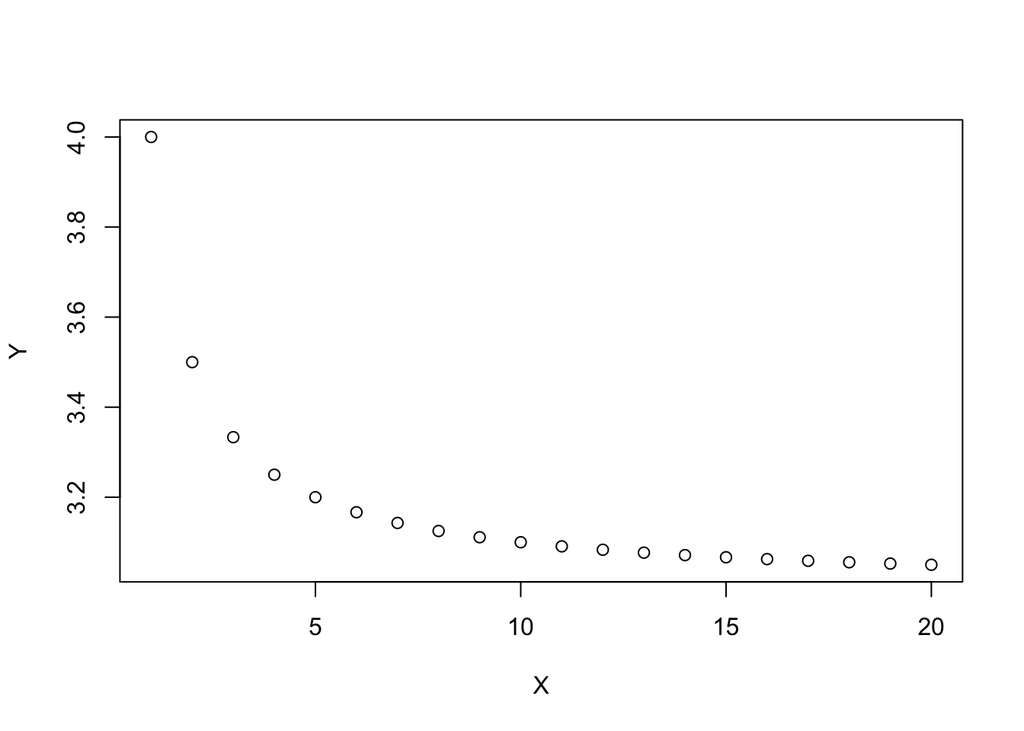

```r
plot(X,Y)
```

Now let’s add in some extra arguments to the plot function to make it prettier

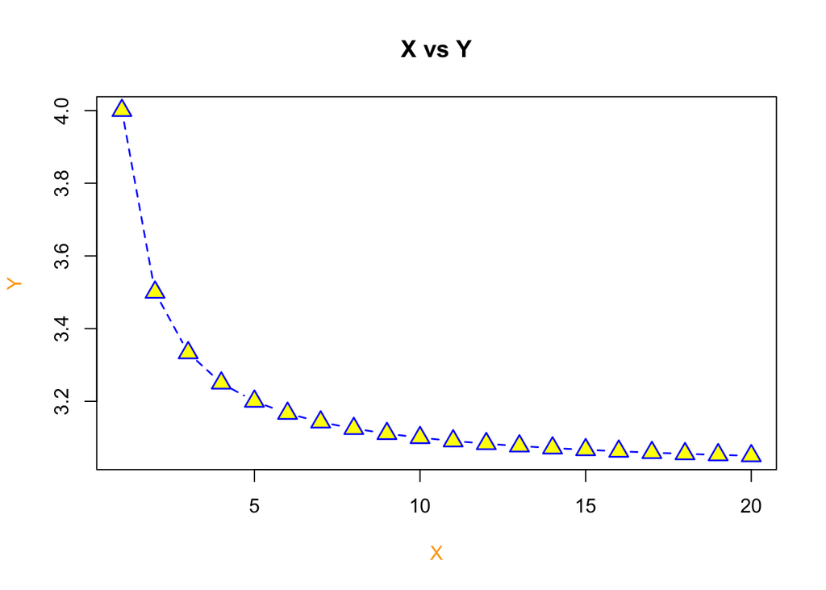

| `plot()` Argument | Definition |
| --- | --- |
| `type` | type of plot - p stands for points |
| `pch` | plotting ‘character’, i.e., symbol to use |
| `col` | color |
| `bg` | background color (only applicable for pch’s between 21:25) |
| `cex` | size of the points |
| `xlab` | x label |
| `ylab` | y label |
| `col.lab` | x and y label color |
| `lwd` | line width |
| `lty` | line type |
| `main` | title of the plot |

```r
plot(x=X,y=Y, type = "b", pch=c(24), col = 'blue', bg='yellow', cex = 1.6, xlab = "X", ylab = "Y",
     col.lab = "orange", lwd=1.4, lty=2, main = "X vs Y")
```

For more argument definitions, use the `help()` function or `?` function like so - `help(plot)` or `?plot`. Multiple options may pop up. This occurs when you have two functions from different packages with the same name. In this case, the `plot()` function we are using is from the `base` package.

### Symbols, Line Types, Color codes

Let’s expand on the arguments described above and show how to add a legend.

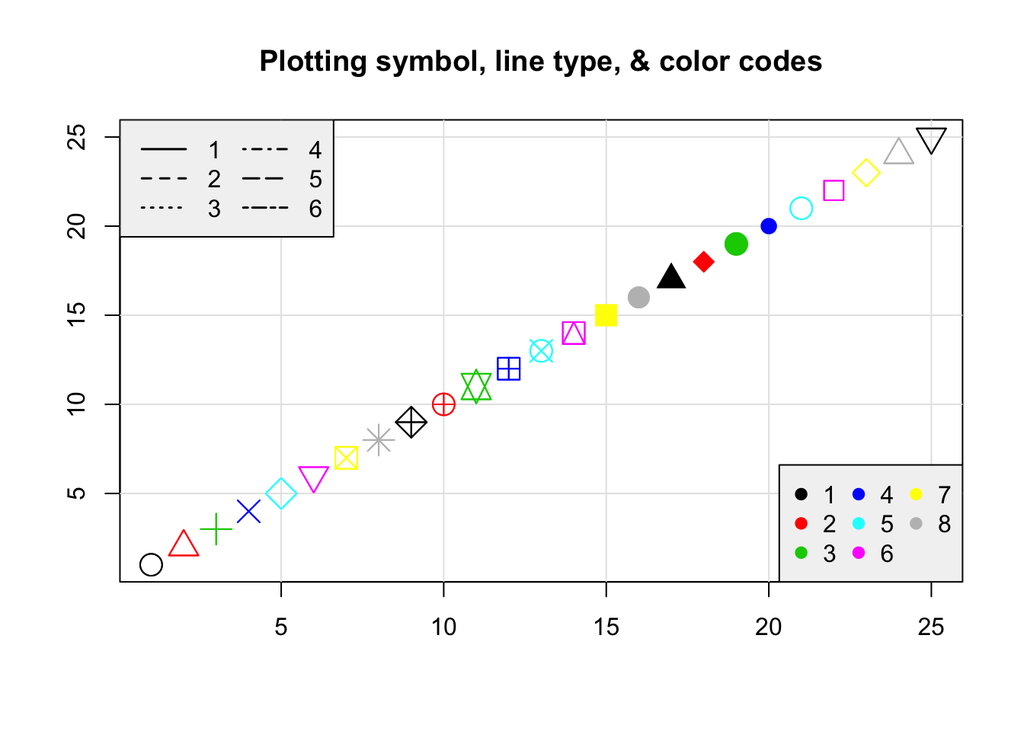

```r
plot(1:25, 1:25, xlab="",ylab="",pch=1:25,col=1:25,cex=2)
grid(lty=1, col="gray90")
points(1:25, 1:25, xlab="",ylab="",pch=1:25,col=1:25,cex=2)
title("Plotting symbol, line type, & color codes")
legend("topleft", legend=1:6, lty=1:6, lwd=1.5, ncol=2, bg="gray95")
legend("bottomright", legend=1:8, col=1:8, ncol=3, pch=19, bg="gray95")
```

## Barplots, Boxplots, Pie Charts

We’re going to create a fake dataset of those who are infected by the coronavirus. Let’s do so using the `sample()` function.

```r
# Create a random sample of the 3 types - Susceptible, Infected and Recovered
InfStatus <- factor(sample(c("Susceptible", "Infected", "Recovered"),size = 50, replace = TRUE))
I <- table(InfStatus)
I
```

```
## InfStatus
##    Infected   Recovered Susceptible
##          19          15          16
```

```r
# Now let's make a random sample of 3 genotypes (RR, Rr, and rr)
Genotype <- factor(sample(c("RR", "Rr", "rr"), size = 50, replace = TRUE))
G <- table(Genotype)
G
```

```
## Genotype
## rr Rr RR
## 14 16 20
```

```r
#show genotype and infected status as a table
table(Genotype, InfStatus)
```

```
##         InfStatus
## Genotype Infected Recovered Susceptible
##       rr        7         4           3
##       Rr        5         7           4
##       RR        7         4           9
```

Note - We turned the sample data info a `factor` to add `levels` (i.e. categories) of our test data.

```r
# WITHOUT the factor
test <- sample(c("Susceptible", "Infected", "Recovered"),size = 50, replace = TRUE)
test
```

```
##  [1] "Recovered"   "Susceptible" "Recovered"   "Infected"    "Susceptible"
##  [6] "Susceptible" "Recovered"   "Susceptible" "Recovered"   "Infected"
## [11] "Susceptible" "Infected"    "Susceptible" "Susceptible" "Recovered"
## [16] "Infected"    "Infected"    "Susceptible" "Infected"    "Infected"
## [21] "Infected"    "Recovered"   "Recovered"   "Infected"    "Susceptible"
## [26] "Susceptible" "Susceptible" "Recovered"   "Recovered"   "Susceptible"
## [31] "Susceptible" "Susceptible" "Susceptible" "Susceptible" "Infected"
## [36] "Recovered"   "Susceptible" "Susceptible" "Infected"    "Susceptible"
## [41] "Infected"    "Recovered"   "Recovered"   "Recovered"   "Susceptible"
## [46] "Infected"    "Susceptible" "Recovered"   "Susceptible" "Infected"
```

```r
class(test)
```

```
## [1] "character"
```

```r
# Now as a factor
test2 <- factor(sample(c("Susceptible", "Infected", "Recovered"),size = 50, replace = TRUE))
test2
```

```
##  [1] Recovered   Infected    Recovered   Susceptible Susceptible Recovered
##  [7] Recovered   Infected    Infected    Susceptible Recovered   Recovered
## [13] Recovered   Infected    Infected    Susceptible Recovered   Susceptible
## [19] Infected    Susceptible Susceptible Recovered   Infected    Susceptible
## [25] Recovered   Recovered   Infected    Infected    Recovered   Infected
## [31] Susceptible Susceptible Recovered   Infected    Recovered   Recovered
## [37] Recovered   Susceptible Recovered   Susceptible Recovered   Recovered
## [43] Susceptible Susceptible Infected    Susceptible Infected    Recovered
## [49] Recovered   Susceptible
## Levels: Infected Recovered Susceptible
```

```r
class(test2)
```

```
## [1] "factor"
```

### Combining Plots

R makes it easy to combine multiple plots into one overall graph, using either the `par()` function. With the `par()` function, you can include the option `mfrow=c(nrows, ncols)` to create a matrix of `nrows` x `ncols` plots that are filled in by row. The Additionally, we can control text size with `cex` - a number indicating the amount by which plotting text and symbols should be scaled relative to the default. 1=default, 1.5 is 50% larger, 0.5 is 50% smaller, etc. Here’s some more descriptions.

| option | description |
| --- | --- |
| `mfrow` | `mfrow=c(nrows, ncols)` - `nrows` x `ncols` plots that are filled in by row |
| `mar` | A numerical vector of the form c(bottom, left, top, right) which gives the number of lines of margin to be specified on the four sides of the plot |
| `oma` | A vector of the form c(bottom, left, top, right) giving the size of the outer margins in lines of text. |
| `bg` | background color |
| `cex` | magnification of text and symbols relative to default. |
| `cex.axis` | magnification of axis annotation relative to `cex` |
| `cex.lab` | magnification of x and y labels relative to `cex` |
| `cex.main` | magnification of titles relative to `cex` |
| `cex.sub` | magnification of subtitles relative to `cex` |

We can always list the `par` settings by entering `par()` in the console. Let’s use these par settings with our test data created above.

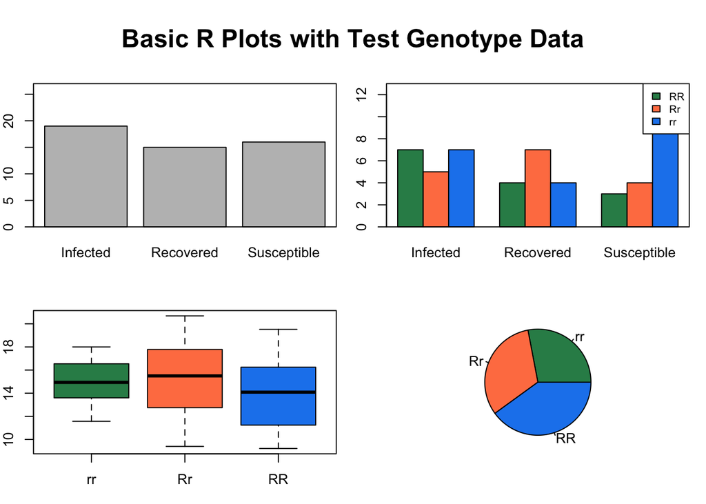

```r
par(mfrow=c(2, 2), mar=c(3, 2, 2, 1), oma=c(0, 0, 3, 0), bg = "white") ## create plot array of 2 row x 2 columns
plot(InfStatus, ylim = c(0, 27)) # basic plot with y limit set as a range
box() # adds a box around the plot coded before this line
barplot(table(Genotype, InfStatus), ylim = c(0, 13), beside = TRUE, col = c("seagreen4", "coral", "dodgerblue2")) # barplot
box() # adds a box around the plot coded before this line
legend("topright", c("RR", "Rr", "rr"), fill = c("seagreen4", "coral", "dodgerblue2"), ncol = 1, cex = 0.75) # legend for the previous plot, which in this case is the barplot
boxplot(rnorm(50, mean = 15, sd = 3) ~ Genotype,  col = c("seagreen4", "coral", "dodgerblue2")) # boxplot
pie(G, col = c("seagreen4", "coral", "dodgerblue2")) # pie plot
mtext("Basic R Plots with Test Genotype Data", outer = TRUE, cex = 1.5, font = 2) # main title
```

## Tree Data

We’re going to download the `TreeData.csv` file from the course github using a direct method. We can use the `download.file()` function to do this.

`download.file(url = "https://github.com/jsimkins2/geog473-673/tree/master/datasets/TreeData.csv", destfile = "/Users/james/Downloads/TreeData.csv" , mode='wb')`

### Loading the Dataset

```r
# Our file location is our destfile argument above. For me, it's /Users/james/Downloads/TreeData.csv
treedat <- read.csv("/Users/james/Documents/Github/geog473-673/datasets/TreeData.csv")
treedat
```

```
##    tree  spp season Infected  dbh SapDepth BarkThick NobarkArea Heartwood
## 1     1 PICO Summer      Yes 42.2      8.4       0.3     1359.2     483.1
## 2     2 ABLA   Fall      Yes 13.4      2.0       0.4      124.7      58.1
## 3     3 ABLA Summer       No 13.1      1.5       0.3      122.7      70.9
## 4     4 PICO Spring       No 15.0      4.1       0.2      167.4      32.2
## 5     5 POTR Winter      Yes 14.2      3.6       0.0      158.4      38.5
## 6     6 POTR Winter      Yes 20.0      5.9       0.0      314.2      52.8
## 7     7 ABLA Summer      Yes  9.1      2.1       0.3       56.7      14.5
## 8     8 ABLA Spring       No  9.2      2.5       0.5       52.8       8.0
## 9     9 ABLA   Fall      Yes 27.3      3.0       0.6      535.0     317.3
## 10   10 PICO   Fall       No 11.2      3.4       0.3       88.2      11.3
## 11   11 PICO Spring      Yes 18.0      5.9       0.3      237.8      24.6
## 12   12 POTR Summer       No  9.0      3.0       0.0       63.6       7.1
## 13   13 POTR Spring       No 15.4      4.1       0.0      186.3      40.7
## 14   14 POTR Winter       No 24.1      6.2       0.0      456.2     107.5
```

[output cut: 27 more lines]

`treedat` is a data frame. As a reminder, a data frame is essentially a 2-dimensional array that contains a *combination* of vectors (columns of data) that are of the class; integer, numeric, character. This is *different* from a matrix which can only contain *1 type* of data. In this case, we have some tree data that includes species of tree, season the data was collected, diameter of the tree, bark thickness, area of no bark, heartwood diameter, and sapwood diameter.

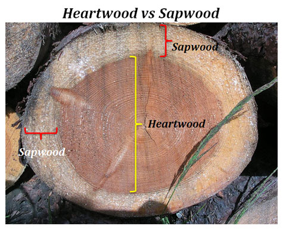

Let’s manipulate this dataframe to make it easier to work wtih.

```r
# let's set the rownames equal to the tree column
treedat <- read.csv("/Users/james/Documents/Github/geog473-673/datasets/TreeData.csv",row.names='tree')
# print treedat
treedat
```

```
##     spp season Infected  dbh SapDepth BarkThick NobarkArea Heartwood SapArea
## 1  PICO Summer      Yes 42.2      8.4       0.3     1359.2     483.1   876.1
## 2  ABLA   Fall      Yes 13.4      2.0       0.4      124.7      58.1    66.6
## 3  ABLA Summer       No 13.1      1.5       0.3      122.7      70.9    51.8
## 4  PICO Spring       No 15.0      4.1       0.2      167.4      32.2   135.2
## 5  POTR Winter      Yes 14.2      3.6       0.0      158.4      38.5   119.9
## 6  POTR Winter      Yes 20.0      5.9       0.0      314.2      52.8   261.3
## 7  ABLA Summer      Yes  9.1      2.1       0.3       56.7      14.5    42.2
## 8  ABLA Spring       No  9.2      2.5       0.5       52.8       8.0    44.8
## 9  ABLA   Fall      Yes 27.3      3.0       0.6      535.0     317.3   217.7
## 10 PICO   Fall       No 11.2      3.4       0.3       88.2      11.3    76.9
## 11 PICO Spring      Yes 18.0      5.9       0.3      237.8      24.6   213.2
## 12 POTR Summer       No  9.0      3.0       0.0       63.6       7.1    56.5
## 13 POTR Spring       No 15.4      4.1       0.0      186.3      40.7   145.5
## 14 POTR Winter       No 24.1      6.2       0.0      456.2     107.5   348.7
## 15 PICO Winter      Yes 24.2      7.0       0.5      422.7      66.5   356.3
## 16 PIFL   Fall       No 14.4      4.2       0.5      141.0      19.6   121.4
## 17 PIFL Winter       No 13.1      2.2       0.6      111.2      44.2    67.0
## 18 PIFL Summer      Yes 21.5      5.1       0.6      323.7      80.1   243.5
## 19 PIFL Spring       No 13.4      2.2       0.5      120.8      50.3    70.5
## 20 PIFL   Fall      Yes 16.2      3.5       0.5      181.5      52.8   128.6
```

```r
# look at the data frame variable names
names(treedat)
```

```
## [1] "spp"        "season"     "Infected"   "dbh"        "SapDepth"
## [6] "BarkThick"  "NobarkArea" "Heartwood"  "SapArea"
```

```r
# print the dbh variable
treedat$dbh
```

```
##  [1] 42.2 13.4 13.1 15.0 14.2 20.0  9.1  9.2 27.3 11.2 18.0  9.0 15.4 24.1 24.2
## [16] 14.4 13.1 21.5 13.4 16.2
```

```r
# rename the dbh variable, but first let's be sure our index of the dbh variable is correct
colnames(treedat)[4]
```

```
## [1] "dbh"
```

```r
# yep, dbh is the index number 4
colnames(treedat)[4] = "tree.diameter"
treedat
```

```
##     spp season Infected tree.diameter SapDepth BarkThick NobarkArea Heartwood
## 1  PICO Summer      Yes          42.2      8.4       0.3     1359.2     483.1
## 2  ABLA   Fall      Yes          13.4      2.0       0.4      124.7      58.1
## 3  ABLA Summer       No          13.1      1.5       0.3      122.7      70.9
## 4  PICO Spring       No          15.0      4.1       0.2      167.4      32.2
## 5  POTR Winter      Yes          14.2      3.6       0.0      158.4      38.5
## 6  POTR Winter      Yes          20.0      5.9       0.0      314.2      52.8
## 7  ABLA Summer      Yes           9.1      2.1       0.3       56.7      14.5
## 8  ABLA Spring       No           9.2      2.5       0.5       52.8       8.0
## 9  ABLA   Fall      Yes          27.3      3.0       0.6      535.0     317.3
## 10 PICO   Fall       No          11.2      3.4       0.3       88.2      11.3
## 11 PICO Spring      Yes          18.0      5.9       0.3      237.8      24.6
## 12 POTR Summer       No           9.0      3.0       0.0       63.6       7.1
## 13 POTR Spring       No          15.4      4.1       0.0      186.3      40.7
## 14 POTR Winter       No          24.1      6.2       0.0      456.2     107.5
```

[output cut: 27 more lines]

Now that our data is curated, let’s create a figure with 2 plots in the window; plot 1 will be a histogram of bark thickness and plot 2 will be a boxplot of sapdepth by species.

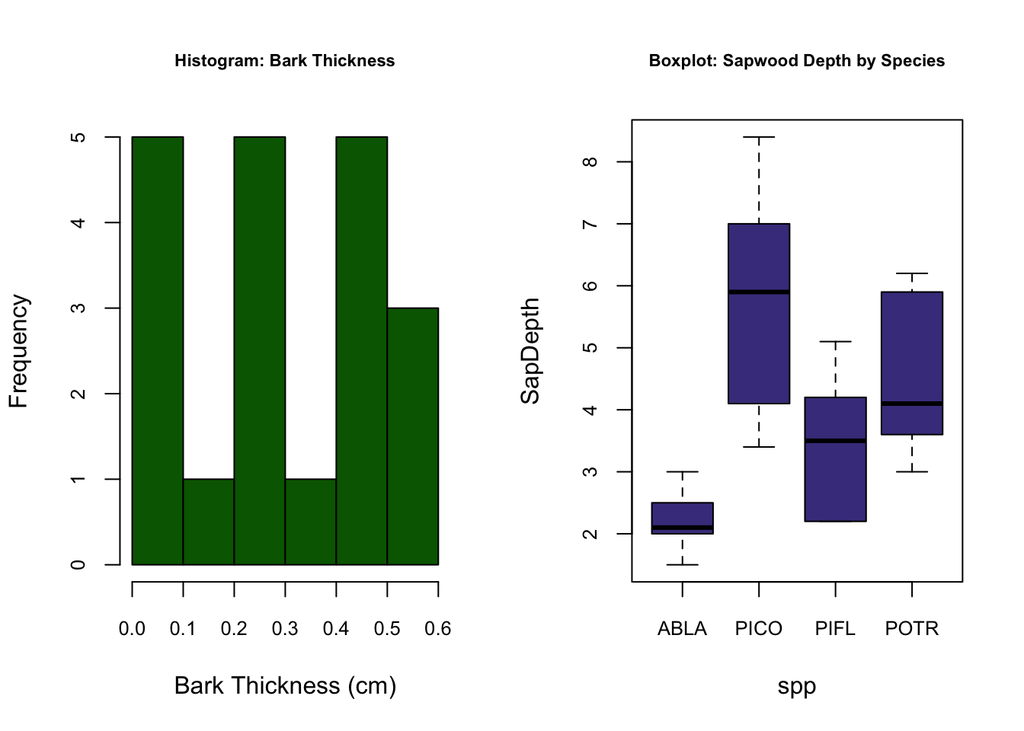

```r
# Now let's do some plotting
par(mfrow=c(1,2)) ## create plot array of 1 row x 2 columns
par(cex.axis=0.8) ## shrinks the name size of the x axes. If we don't do this, not all the names in the boxplot show up
par(cex.main=0.7) ## shrinks the name size of the titles. If we don't do this, the titles don't fit in the window
# Use the his() function to plot a histogram
hist(treedat$BarkThick, xlab= "Bark Thickness (cm)", main= "Histogram: Bark Thickness", col= "darkgreen")
boxplot(SapDepth ~ spp, data= treedat, ylab= "SapDepth", col= "darkslateblue", main= "Boxplot: Sapwood Depth by Species")
```

`hist()` is the histogram function; `boxplot()` is the boxplot function. The `boxplot()` function using a slightly different syntax for plotting in the form of `y ~ x`, or **y versus x**. `hist()`, on the other hand, can only plot numerical values. For categorical data, such as our tree species column, must be plotted with `barplot()` and the `table()` function.

```r
# print the table function output of treedat$spp - notice the categorical help from the table function
table(treedat$spp)
```

```
##
## ABLA PICO PIFL POTR
##    5    5    5    5
```

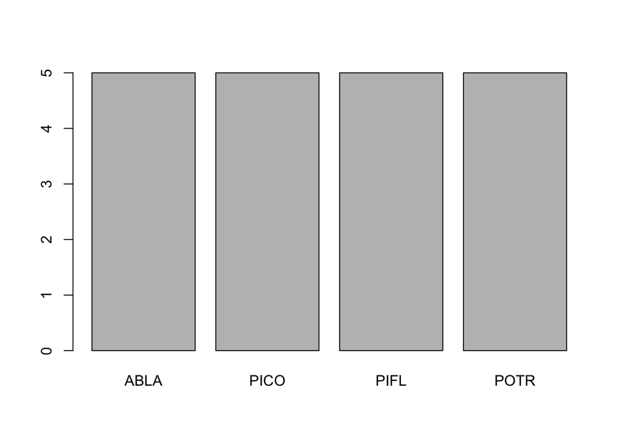

```r
# plot this categorical data using barplot() function
barplot(table(treedat$spp))
```

[figure not shown]

```r
# customize the barplot function
barplot(table(treedat$spp), main="SPP Count Barplot",
xlab="SPP",
ylab="Count",
border="red",
col="blue",
density=10)
```

## Assignment:

[figure not shown]

Your final plot should look like this

[figure not shown]